# Predicting How Points End in Tennis

## kNN & Neuron Network

**a. kNN (K-Nearest Neighbour)**

- kNN method is: if most of the k similar samples in the feature space (that is, the closest samples in the feature space) belong to a certain category, the sample also belongs to this category.
- After normalizing tennis related variables by applying the function (x - min(x)) / (max(x) - min(x)) which limit all numeric data to a range between 0 and 1, we train our model through kNN () function.
- *Libraries used: class, KODAMA, caret*

**b. Neural Network**

- The motivation behind using Neural Networks on the AO Tennis dataset was to utilise the deep learning nature to build an accurate model to classify the point endings.
- To determine whether our neural network would classify the dataset well, we first divided the data into a training set (67%) and test set (33%). This allowed us to determine how many neurons to include in the hidden layer based on the accuracy of the model.
- *Libraries used: neuralnet*

## XGBoost

- The motivation behind using XGBoost was **due to the iterative alterations** to the weights during the tree building process and an in-built regularisation system.
- The issue with using a random forest model (our base model) was the random nature of the model.
- All explanatory variables were converted from characters into numerics.

**Parameter Tuning**

- Maximum tree depth: 6
- Classification Objective: Multiclass Probabilities
- Evaluation Metric: Multiclass Log-Loss
- Stopping Rounds Threshold: 200
- Learning Rate: 0.15

**Feature Engineering**

- New Variables such as **Rally_info, Aces, Gender and Other Variables** were derived off the raw data.
- **Rally_info** increase in approximately 1.5% was seen using the random forest classification method.

## XGBoost - Result

- XGBoost showed assuring signs of improvement from the other models from the resulting classification error.
- Along with the aforementioned features, it was able to classify around 91.5% of the dataset correctly. Predictions with the hidden test set on Kaggle returned an accuracy of 92.6%.

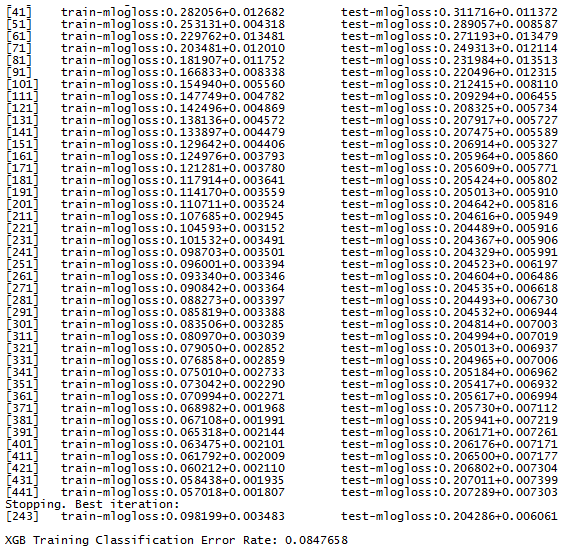

## Conclusion

- The classifications methods explored include **the Random Forest Method, XGBoost, Neural Network and K-nearest neighbours.**
- Of these methods, the **XGBoost method** was found to be the most effective.
- To further improve the accuracy of our model, some feature engineering was undertaken.
- From this process, we deduced the **aces, rally.info, sex, game, set and match id.**
- Thus, we utilized the additional variables **rally.info and aces** with the optimised XGBoost method.